# Cuestionario 2 · Diseño Experimental y Bioestadística

Bioestadística · Semana 1 · 2026-II

Este cuestionario acompaña el Taller 1. Diseño Experimental en R y cierra el bloque de diseño experimental de la Semana 1.

Autor/a

[Javier Rodríguez-Barrios](https://www.unimagdalena.edu.co/)

Fecha de publicación

4 de octubre de 2026

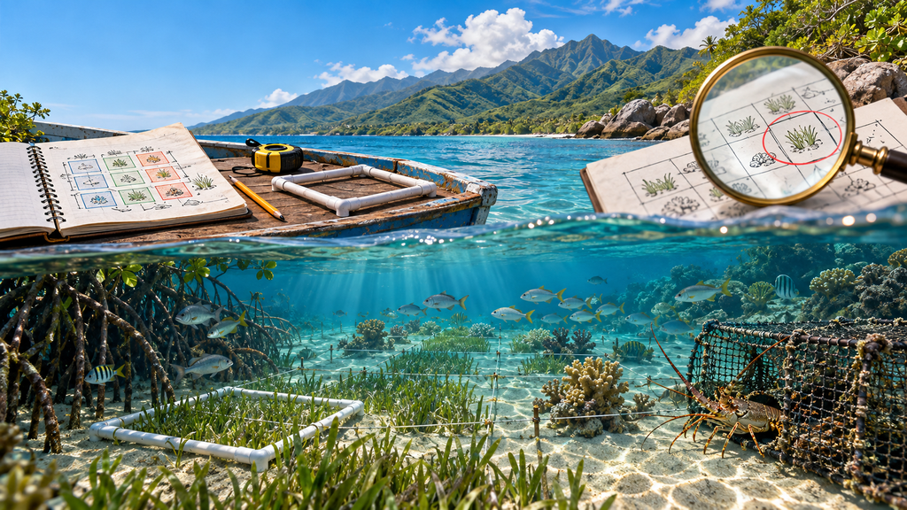

## Cuestionario 2

Este cuestionario acompaña al Taller 1 y al **Cuestionario 1** de opción múltiple. Mientras el Cuestionario 1 evalúa si se reconoce la respuesta correcta, el Cuestionario 2 entrena dos habilidades necesarias para un proyecto de grado propio: **proponer** un diseño desde cero, y **detectar** cuándo un diseño (propio o ajeno) tiene un problema importante. Tiene tres partes:

- **Parte A — Diseñar:** 4 escenarios nuevos, uno por cada tipo de diseño del Taller 1. No se indica de entrada qué tipo es.
- **Parte B — Encontrar el error:** 4 viñetas de diseños ya “ejecutados”, cada una con exactamente uno de los 4 errores vistos en las diapositivas (pseudoreplicación, confusión de factores, falta de aleatorización, ausencia de control). El trabajo consiste en diagnosticar, no en calcular.
- **Parte C — Proyecto propio:** 2 preguntas que llevan el cierre del Taller 1 a la idea de investigación propia.

**ImportanteRuta mínima calificable (45 pts · rúbrica R1)**

| Parte | Qué se entrega | Criterio de R1 |
| --- | --- | --- |
| **A — Diseñar** | **2 de los 4 escenarios** (A1 a A4), a elección | 1. Razonamiento y elección (20) · 2. Ejecución e interpretación (15) |
| **B — Encontrar el error** | **2 de las 4 viñetas** (B1 a B4), a elección | 1. Razonamiento y elección · 2. Ejecución e interpretación |
| **C — Proyecto propio** | **C1 y C2** (obligatorias) | 3. Proyecto propio (10) |

- Al inicio de la entrega se indica qué escenarios y qué viñetas se eligieron. Si no se indica, se califican los dos primeros que aparezcan resueltos en cada parte.
- Los ejercicios que no forman parte de la ruta elegida quedan como práctica: no suman ni restan.
- Se entrega en Moodle el `.qmd` con la ruta mínima resuelta y su render (HTML o PDF). Cierra el **jueves 15 de octubre, 23:59**. La tarea se habilita al completar la práctica de opción múltiple (Cuestionario 1).

Las respuestas no se incluyen en esta versión: se discuten en clase después del cierre de la entrega. Conviene ejecutar el código de cada escenario y razonar la respuesta antes de escribirla.

#### Parte A — Diseñar: escenarios nuevos

**Tip**

**Ruta mínima:** resolver **2 de los 4 escenarios** (A1 a A4), a elección. Los demás quedan como práctica.

##### A1 — Dispositivo excluidor de tortugas (TED)

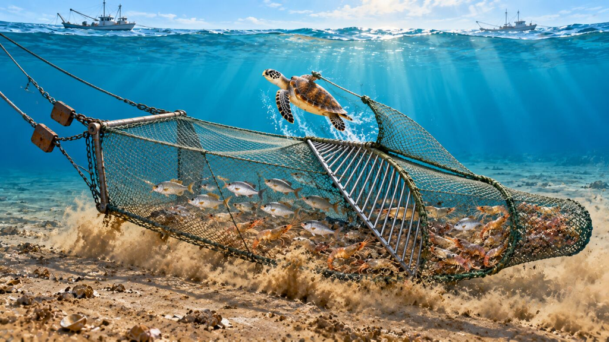

**NotaEl contexto**

Un equipo de manejo pesquero quiere saber si instalar un **dispositivo excluidor de tortugas (TED)** en las redes de arrastre artesanal reduce la captura incidental de tortugas carey juveniles. Trabajan en **3 zonas de pesca** (Norte, Centro, Sur) que, por su batimetría y corrientes, se sabía de antemano que tienen niveles base de captura incidental distintos. En cada zona probaron 4 faenas con red convencional y 4 con red equipada con TED.

1. ¿Cuál es la unidad experimental?
2. Las 3 zonas tienen niveles base de captura distintos, algo que el equipo **ya sabía antes de salir a pescar**. ¿Qué principio de diseño aprovecha esa información a favor del análisis?
3. ¿Qué tipo de diseño es este?
4. Escribir la fórmula de `aov()` que se usaría.

**Código**

```r
set.seed(2026)            # Fijar la semilla

zona <- gl(3, 8,
           labels = c("Zona_Norte", "Zona_Central",
                      "Zona_Sur"))                    # Crea zonas

ted <- gl(2, 4, 24,
          labels = c("Sin_TED", "Con_TED"))           # Crea tratamientos

efecto_ted <- c(Sin_TED = 0, Con_TED = -4.5)[ted]     # Define efecto TED

efecto_zona <- c(Zona_Norte = 0, Zona_Central = 3,
                 Zona_Sur = -2)[zona]                 # Define efecto zona

capturas_tortuga <- round(
  pmax(0, rnorm(24,
                mean = 9 + efecto_ted + efecto_zona,
                sd = 2)))                             # Genera capturas

bycatch <- data.frame(
  zona, ted, capturas_tortuga)                        # Crea tabla

str(bycatch)                                          # Explora estructura
```

```
'data.frame':   24 obs. of  3 variables:
 $ zona            : Factor w/ 3 levels "Zona_Norte","Zona_Central",..: 1 1 1 1 1 1 1 1 2 2 ...
 $ ted             : Factor w/ 2 levels "Sin_TED","Con_TED": 1 1 1 1 2 2 2 2 1 1 ...
 $ capturas_tortuga: num  10 7 9 9 3 0 3 2 12 11 ...
```

Conviene ejecutar una propuesta de análisis antes de seguir leyendo.

##### A2 — Erizos entre arrecifes

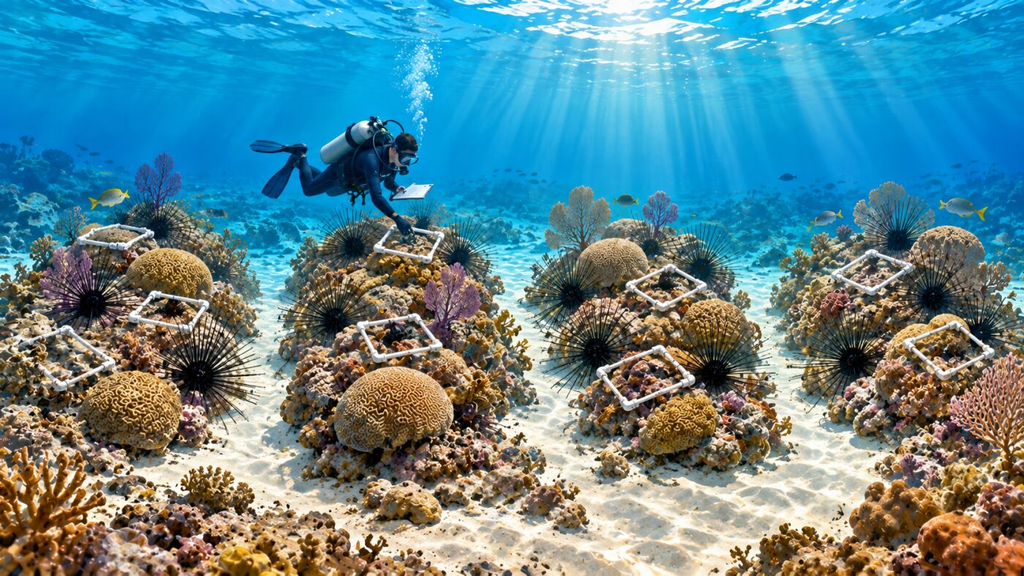

**NotaContexto**

Un equipo quiere comparar la abundancia de erizos de mar (*Diadema antillarum*) entre **4 arrecifes** con profundidad, tipo de sustrato y exposición al oleaje muy similares entre sí — no hay ninguna razón conocida para esperar que un arrecife sea sistemáticamente distinto de otro antes de muestrear. Contaron erizos en 7 cuadrantes por arrecife.

1. ¿Hay alguna fuente de variación conocida de antemano que deba controlarse?
2. ¿Qué tipo de diseño es este?
3. Escribir la fórmula de `aov()` que se usaría.

**Código**

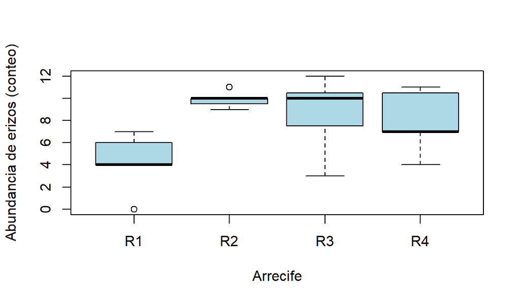

```r
set.seed(2026)         # Fijar la semilla

arrecife <- gl(4, 7,
               labels = c("R1", "R2", "R3", "R4"))        # Crea arrecifes

medias_ar <- c(R1 = 6, R2 = 11, R3 = 9, R4 = 7)[arrecife] # Asigna medias

erizos <- round(
  pmax(0, rnorm(28, mean = medias_ar, sd = 2.3))
)                                                         # Genera abundancias

diadema <- data.frame(
  arrecife, erizos)                                       # Crea tabla

boxplot(
  erizos ~ arrecife,
  data = diadema,
  col = "lightblue",
  xlab = "Arrecife",
  ylab = "Abundancia de erizos (conteo)")                 # Grafica distribución
```

##### A3 — Luz y nutrientes en piscinas intermareales

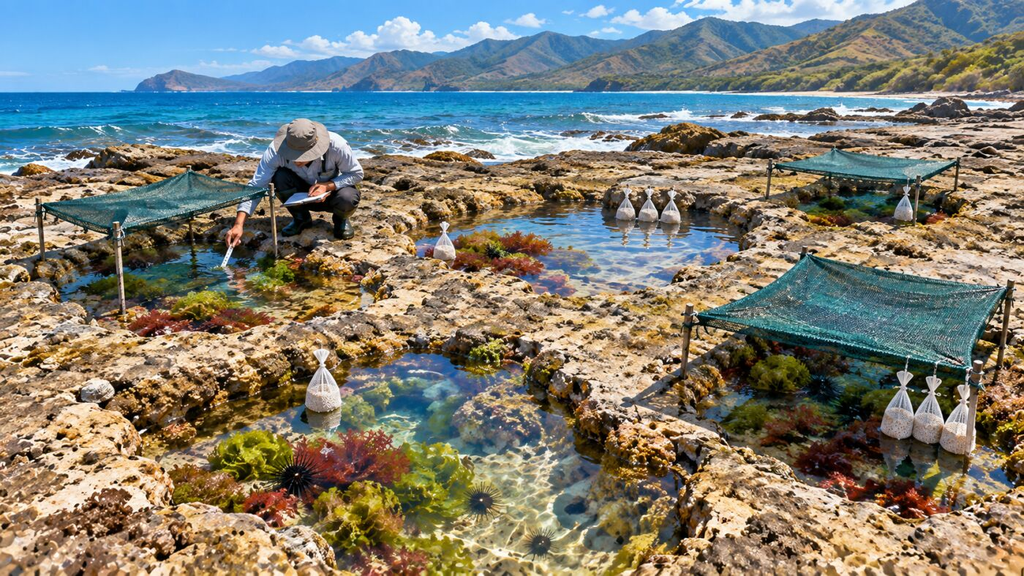

**NotaEl contexto**

Un equipo quiere saber si la **exposición solar** (sol pleno / sombra) y el **enriquecimiento de nutrientes** (ninguno / bajo / alto) afectan el crecimiento de macroalgas en piscinas intermareales — y, sobre todo, si el efecto de la luz depende del nivel de nutrientes disponible. Cruzaron ambos factores con 3 réplicas por combinación.

1. ¿Cuántos factores hay, y qué pregunta específica (más allá del efecto de cada uno por separado) motiva cruzarlos?
2. ¿Qué tipo de diseño es este?
3. Escribir la fórmula de `aov()` que se usaría.

**Código**

```r
set.seed(2026)                                      # Fija semilla

luz <- gl(2, 3, 18,
          labels = c("Sol_pleno", "Sombra"))          # Crea niveles luz

nutrientes <- gl(3, 1, 18,
                 labels = c("Ninguno", "Bajo", "Alto")) # Crea nutrientes

mu_a3 <- matrix(
  c(18, 22, 28,
    18, 19, 20),
  nrow = 2,
  byrow = TRUE,
  dimnames = list(
    c("Sol_pleno", "Sombra"),
    c("Ninguno", "Bajo", "Alto")
  )
)                                                    # Define medias

medias_a3 <- mu_a3[
  cbind(as.integer(luz), as.integer(nutrientes))
]                                                    # Asigna medias

crecimiento_macroalgas <- round(
  pmax(0, rnorm(18, mean = medias_a3, sd = 2)), 1)   # Genera crecimiento

piscinas <- data.frame(
  luz, nutrientes, crecimiento_macroalgas)           # Crea tabla

str(piscinas)                                        # Explora estructura
```

```
'data.frame':   18 obs. of  3 variables:
 $ luz                   : Factor w/ 2 levels "Sol_pleno","Sombra": 1 1 1 2 2 2 1 1 1 2 ...
 $ nutrientes            : Factor w/ 3 levels "Ninguno","Bajo",..: 1 2 3 1 2 3 1 2 3 1 ...
 $ crecimiento_macroalgas: num  19 19.8 28.3 17.8 17.7 15 16.5 20 28.2 17.1 ...
```

##### A4 — Restauración de pastos marinos: sedimento y densidad

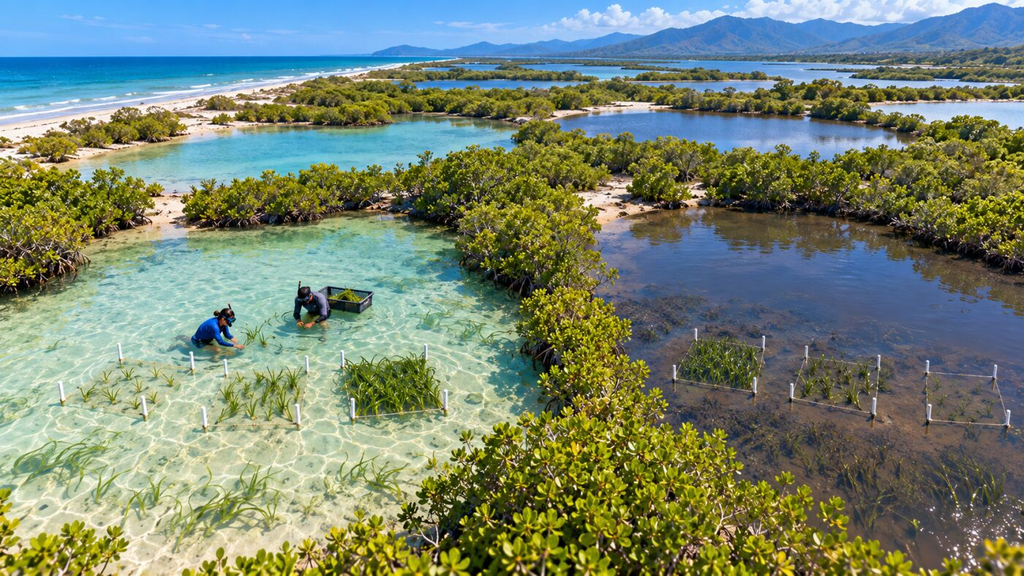

**NotaEl contexto**

Un proyecto de restauración de pastos marinos quiere comparar dos **tipos de sedimento** (arenoso / fangoso) y tres **densidades de siembra** (baja / media / alta). El tipo de sedimento es una característica de toda la **laguna costera** — no se puede cambiar la composición del sedimento en una sola parcela dentro de la laguna, es una propiedad de la laguna completa. La densidad de siembra, en cambio, sí se puede variar libremente dentro de cada laguna, parcela por parcela. Trabajaron en 6 lagunas (3 de cada tipo de sedimento), con 3 parcelas de densidad distinta en cada una.

1. ¿A qué escala se puede asignar cada factor: laguna completa, o parcela dentro de la laguna?
2. ¿Qué tipo de diseño es este, y por qué **no** es simplemente un factorial como el ejercicio A3?
3. Escribir la fórmula de `aov()` que se usaría, incluyendo el término `Error()` si corresponde.

**Código**

```r
set.seed(2026)               # Fijar la semilla

sedimento <- gl(2, 9, 18,
                labels = c("Arenoso", "Fangoso"))     # Crea sedimentos

laguna <- factor(rep(1:6, each = 3))                  # Crea lagunas

densidad_siembra <- gl(
  3, 1, 18,
  labels = c("Baja", "Media", "Alta"))                # Crea densidades

efecto_sed <- c(Arenoso = 0, Fangoso = -8)[sedimento] # Define efecto sedimento

efecto_dens <- c(
  Baja = 0, Media = 5, Alta = 8
)[densidad_siembra]                                   # Define efecto densidad

efecto_laguna <- rep(
  rnorm(6, mean = 0, sd = 2),
  each = 3
)                                                    # Añade variación

supervivencia_pastos <- round(
  pmax(0, pmin(100,
      55 + efecto_sed + efecto_dens +
        efecto_laguna +
        rnorm(18, sd = 2))), 1)                     # Genera supervivencia

restauracion <- data.frame(
  sedimento, laguna, densidad_siembra,
  supervivencia_pastos)                             # Crea tabla

str(restauracion)                                   # Explora estructura
```

```
'data.frame':   18 obs. of  4 variables:
 $ sedimento           : Factor w/ 2 levels "Arenoso","Fangoso": 1 1 1 1 1 1 1 1 1 2 ...
 $ laguna              : Factor w/ 6 levels "1","2","3","4",..: 1 1 1 2 2 2 3 3 3 4 ...
 $ densidad_siembra    : Factor w/ 3 levels "Baja","Media",..: 1 2 3 1 2 3 1 2 3 1 ...
 $ supervivencia_pastos: num  54.6 59 64.3 51.9 57 59.4 54.8 59.8 58.2 49.5 ...
```

#### Parte B — Encontrar el error: diagnóstico de diseños fallidos

**Tip**

**Ruta mínima:** resolver **2 de las 4 viñetas** (B1 a B4), a elección. Las demás quedan como práctica.

Cada viñeta describe un estudio ya “hecho”, con exactamente uno de los 4 errores de la diapositiva “Errores que invalidan un diseño”. Se debe identificar cuál, y cómo se rediseñaría.

##### B1 — Abundancia de peces en dos áreas marinas protegidas

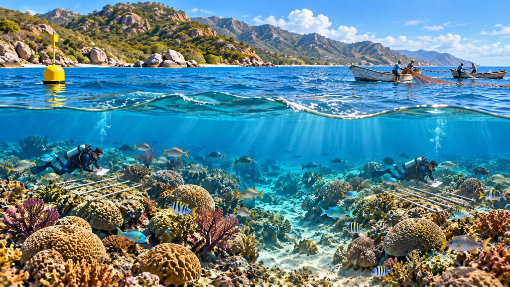

**NotaLa viñeta**

Un investigador quiere comparar la abundancia de peces entre un área marina protegida (AMP) de no-pesca y una zona de uso múltiple. Seleccionó **1 sitio representativo** de cada tipo, y dentro de cada sitio hizo **20 transectos de censo visual**. Corrió un t-test tratando los 40 transectos (20 + 20) como 40 observaciones independientes.

1. ¿Cuál es la unidad experimental real: el transecto, o el sitio?
2. Con esa unidad experimental real, ¿cuántas réplicas verdaderas tiene cada grupo?
3. ¿Qué error de diseño es este?

**Código**

```r
set.seed(2026)                                      # Fija semilla

efecto_sitio_amp1 <- rnorm(1, mean = 0, sd = 4)      # Genera efecto sitio

efecto_sitio_amp2 <- rnorm(1, mean = 0, sd = 4)      # Genera efecto sitio

abundancia_amp1 <- round(
  pmax(0, rnorm(20,
                mean = 30 + efecto_sitio_amp1,
                sd = 2)))                            # Genera abundancia

abundancia_amp2 <- round(
  pmax(0, rnorm(20,
                mean = 30 + efecto_sitio_amp2,
                sd = 2)))                            # Genera abundancia
```

##### B2 — Técnica de restauración de coral

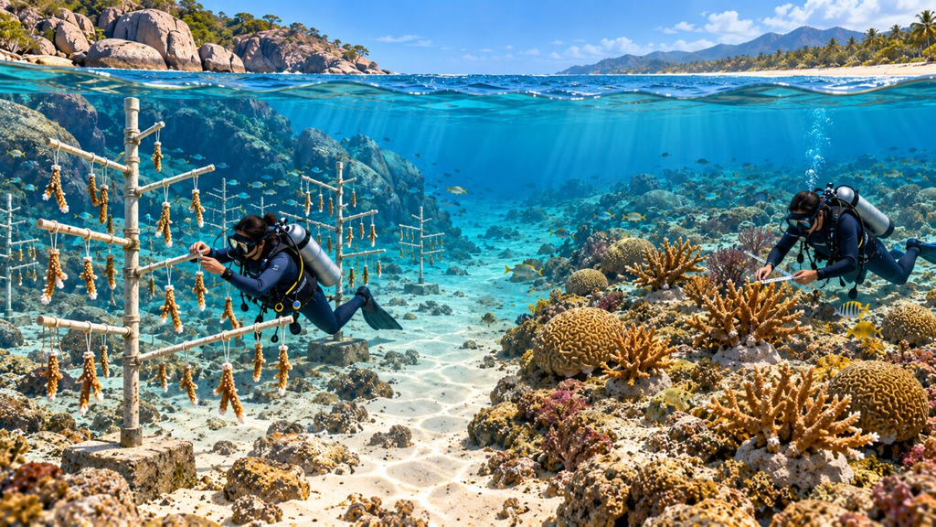

**NotaLa viñeta**

Un equipo compara dos técnicas de restauración coralina — fragmentación asistida vs. trasplante directo. Por razones logísticas, la **técnica de fragmentación se aplicó solo en el Sitio X**, y el **trasplante directo solo en el Sitio Y**. Midieron el crecimiento de 15 colonias en cada sitio y compararon las técnicas con un t-test.

1. ¿Qué cambia junto con la técnica, sin que el diseño lo pueda separar?
2. Si encuentran una diferencia significativa entre técnicas, ¿pueden atribuirla honestamente a la técnica?
3. ¿Qué error de diseño es este?

**Código**

```r
set.seed(2026)             # Fija semilla

n_frag <- 15                                         # Define réplicas

sitio_efecto_X <- 8                                  # Define efecto X
sitio_efecto_Y <- 0                                  # Define efecto Y

crecimiento_A_sitioX <- round(
  pmax(0, rnorm(n_frag,
                mean = 20 + sitio_efecto_X,
                sd = 3)), 1)                         # Genera crecimiento

crecimiento_B_sitioY <- round(
  pmax(0, rnorm(n_frag,
                mean = 20 + sitio_efecto_Y,
                sd = 3)), 1)                         # Genera crecimiento
```

##### B3 — Selección de sitios por accesibilidad

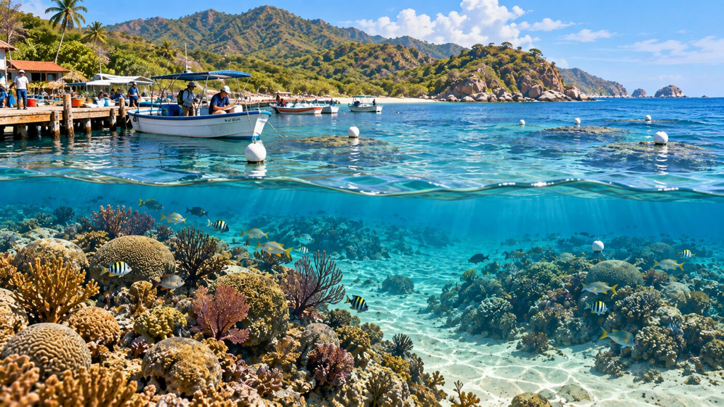

**NotaLa viñeta**

Para comparar la cobertura de coral entre una zona con alto tráfico de embarcaciones y una con bajo tráfico, un estudiante eligió los sitios de muestreo de la zona de alto tráfico entre los **más cercanos y accesibles en bote desde el muelle**, y los sitios de la zona de bajo tráfico entre los **más alejados y de difícil acceso**, “para ahorrar tiempo de navegación”.

1. ¿Qué otras características ambientales podrían estar correlacionadas con “qué tan accesible es un sitio en bote” (profundidad, protección del oleaje, cercanía a la costa)?
2. ¿Qué error de diseño es este?

##### B4 — Dosis de fertilizante en restauración de pastos marinos

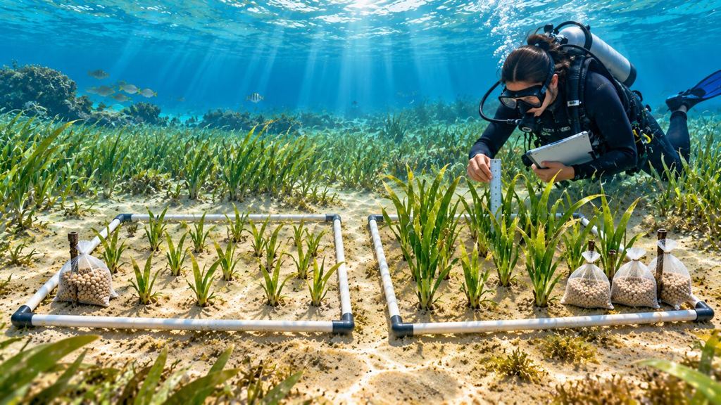

**NotaLa viñeta**

Un proyecto de restauración prueba dos dosis de un fertilizante nuevo (dosis baja, dosis alta) sobre el crecimiento de plántulas de pasto marino trasplantadas. No incluyeron un grupo sin fertilizante, “porque el interés es solo comparar las dos dosis entre sí”. Encontraron que la dosis alta produce más crecimiento que la baja, y concluyeron que el fertilizante mejora la restauración.

1. Con este diseño, ¿pueden saber si *cualquier* dosis de fertilizante mejora el crecimiento frente a no aplicar nada?
2. ¿Qué error de diseño es este?

#### Parte C — Proyecto propio

**Tip**

**Ruta mínima:** **C1 y C2 son obligatorias**. Se califican con el criterio 3 de la rúbrica R1 (10 pts).

Esta parte retoma el cierre del Taller 1 («El diseño de un estudio propio»): adaptar lo visto a la idea de investigación propia antes de salir a campo. Como la cohorte apenas inicia, basta con una **idea tentativa**, aunque sea preliminar. No hay una respuesta única: se valora que la aplicación sea coherente con el tema del taller y específica para el sistema de estudio, no una copia de los ejemplos del taller.

##### C1 — Una idea tentativa y su estructura de diseño

**NotaLa consigna**

Escribir en una frase la idea tentativa de investigación: sistema, organismo o variable de interés, y la pregunta. A partir de esa frase:

1. ¿Cuál sería la unidad experimental (o muestral) y cuál la unidad de observación?
2. ¿Hay alguna fuente de variación conocida de antemano (temporada, zona, profundidad, sitio) que convenga controlar? ¿Algún factor solo podría asignarse a una escala mayor que otro?
3. Con base en lo anterior, ¿cuál de los cuatro diseños del Taller 1 (completamente al azar, bloques al azar, factorial, parcelas divididas) se ajusta mejor a la idea? Justificar en 2 o 3 frases.

##### C2 — Poner a prueba el diseño con datos simulados

**NotaLa consigna**

1. Copiar el código de la Parte del Taller 1 que corresponda al diseño elegido en C1 (Parte 1: CA; Parte 2: bloques; Parte 3: factorial; Parte 4: parcelas divididas).
2. Reemplazar los nombres de las variables, los niveles de los factores, el número de réplicas y las medias simuladas por valores plausibles para el sistema de estudio propio. Indicar de dónde salen esos valores (literatura, estudio piloto o criterio propio).
3. Ajustar el `aov()` correspondiente y responder: ¿la salida de R tiene sentido con lo planteado? ¿Cuál de los cuatro errores de la Parte B sería el mayor riesgo para este diseño en campo, y cómo se evitaría?

**Código**

```r
# Reemplazar este bloque por la simulación propia y cambiar
# "eval: false" por "eval: true" antes de renderizar.
set.seed(2026)                                       # Fija semilla

# factor_1 <- gl(...)                                # Crea factores
# respuesta <- rnorm(...)                            # Genera respuesta
# datos_propios <- data.frame(...)                   # Crea tabla
# mod_propio <- aov(respuesta ~ ..., data = datos_propios)  # Ajusta modelo
# summary(mod_propio)                                # Muestra ANOVA
```

#### Cierre

Los 8 ejercicios de las Partes A y B cubren, de extremo a extremo, lo que se hará una y otra vez al diseñar un proyecto de investigación propio: mirar un sistema aún desconocido, decidir qué estructura de diseño le queda, y —igual de importante— revisar el propio diseño (o el de un compañero) buscando estos mismos 4 errores antes de salir a campo. Ese hábito de revisión es, en la práctica, más valioso que memorizar cuál fórmula de `aov()` usar.

## Referencias

- Quinn, G. P., & Keough, M. J. (2024). *Experimental Design and Data Analysis for Biologists* (2nd ed.). Cambridge University Press. — Capítulos sobre diseños de bloques, factoriales y de parcelas divididas. ([enlace_ejercicios](https://mjkeough.github.io/examples.html))
- Logan, M. (2011). *Biostatistical Design and Analysis Using R*. Wiley-Blackwell. — Capítulo sobre asignación aleatoria de tratamientos y estructura de diseños. ([enlace_ejercicios](https://bcs.wiley.com/he-bcs/Books?action=index&bcsId=5684&itemId=1405190086))

**Nota**

Los ejemplos y datasets de este taller son de elaboración propia para este curso; no reproducen los ejercicios ni el código de las fuentes citadas.